# Summer 2017 Stat 135 final (take home part)

### b)

Examine the residuals and comment whether the assumptions of the standard statistical model are satisfied.

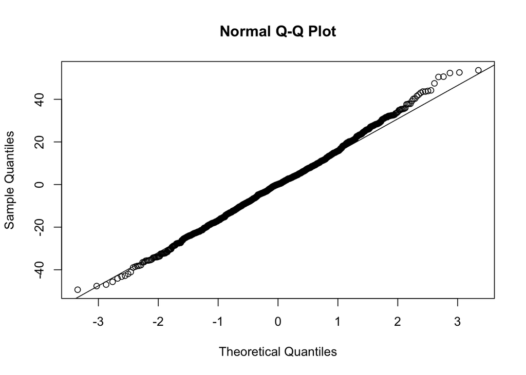

```r
x <- infants$gestation
y<- infants$bwt
df <- data.frame(x,y)
df<-na.omit(df)


NewModel.lm.resid<- residuals(NewModel)
qqnorm(NewModel.lm.resid)
qqline(NewModel.lm.resid)
```

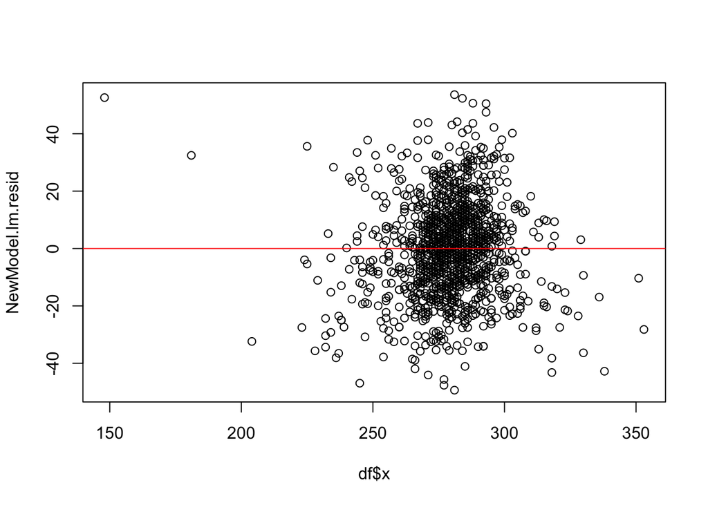

```r
resplot<- plot(df$x, NewModel.lm.resid) +abline(h=0, col="red")
```

```r
resplot
```

```
## integer(0)
```

```r
#from the residual plot we can confirm what we know from the residuals, that their expected value is equal to 0. This evident as we  see that the points are evenly distributed above and and below the y=0 line, which means that they do not follow any particular pattern(as it should be )

#the residual plot in combination with the qqplot (near a straight line) allows to see that the points follow a normal distribution, which are part of the assumptions required for the standard statistics model.
```

### c)

Assuming the model is reasonable, what birthweight would you predict to have if a baby has a gestation period of 300 days?

```r
y= 0.4283521*(300)
y
```

```
## [1] 128.5056
```

```r
# from our new model( the one that excludes the intercept) we can predict to have a baby that wights 128 at birth.
```

# Question 4

We wish to compare the mean gestation birth weight (`bwt`) of mothers who smoke (`smoke=Now`) versus mothers who don’t smoke (`smoke=Never`). I will help you with data cleaning and then I want you to do a statistical analysis of whether birthweights are significantly different if mothers smoke or not.

Lets create a smaller data frame from `infants` consisting of two variables `gestation` and `smoke`. We will eliminate observations if the `smoke` doesn’t take the value `smoke=Never` or `smoke=Now`.

```r
library(dplyr)
smoke <- infants$smoke
gestation <- infants$gestation
df <- data.frame(smoke, gestation)
df <- df %>% filter(smoke=="Never" |  smoke =="Now") #make data frame where smoke variable takes only two values, "Never" or "Now"
head(df)
```

```
##   smoke gestation
## 1 Never       284
## 2 Never       282
## 3   Now       279
## 4   Now       282
## 5 Never       244
## 6 Never       245
```

The data frame `df` is in tidy format (see lecture 14 in class exercises).

### a)

Make a boxplot to examine `gestation` as a function of `smoke`. What do you conclude?

```r
smoke <- infants$smoke
gestation <- infants$gestation
df <- data.frame(smoke, gestation)
df <- df %>% filter(smoke=="Never" |  smoke =="Now") #make data frame where smoke variable takes only two values, "Never" or "Now"
head(df)
```

```
##   smoke gestation
## 1 Never       284
## 2 Never       282
## 3   Now       279
## 4   Now       282
## 5 Never       244
## 6 Never       245
```

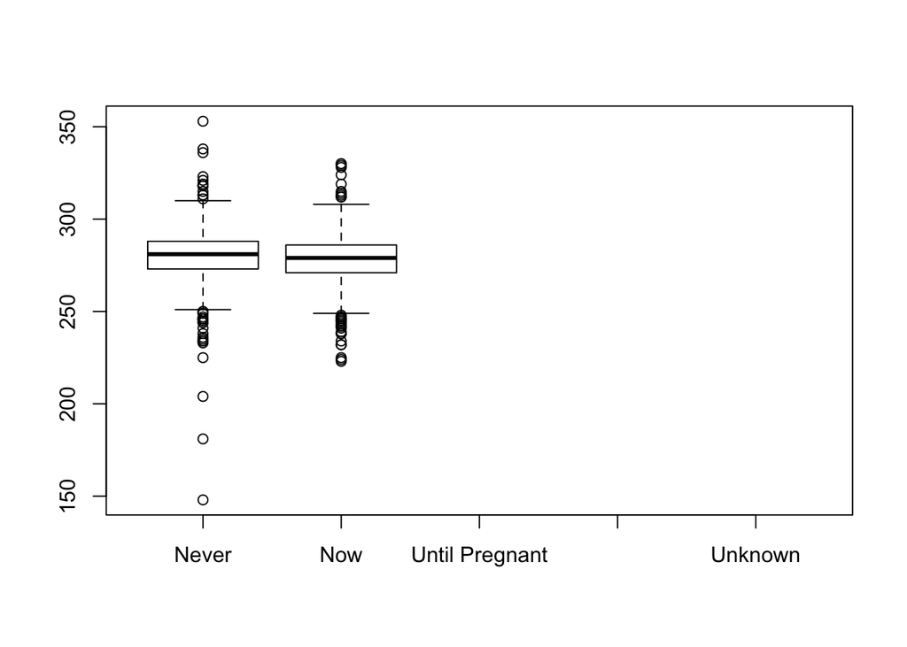

```r
boxplot(formula=df$gestation~df$smoke)
```

```r
#the group people who have never smokes appears to have more outliers. Also they appear to have a slightly longer gestation period.The avgs appear to be about the same for both, and they both seem to follow a normal distribution
```

### b)

Make a check of the assumption that the distributions of `gestation` are normal by making a Normal Q-Q plot. Also make a plot to check that the variances are the same. What are your conclusions?

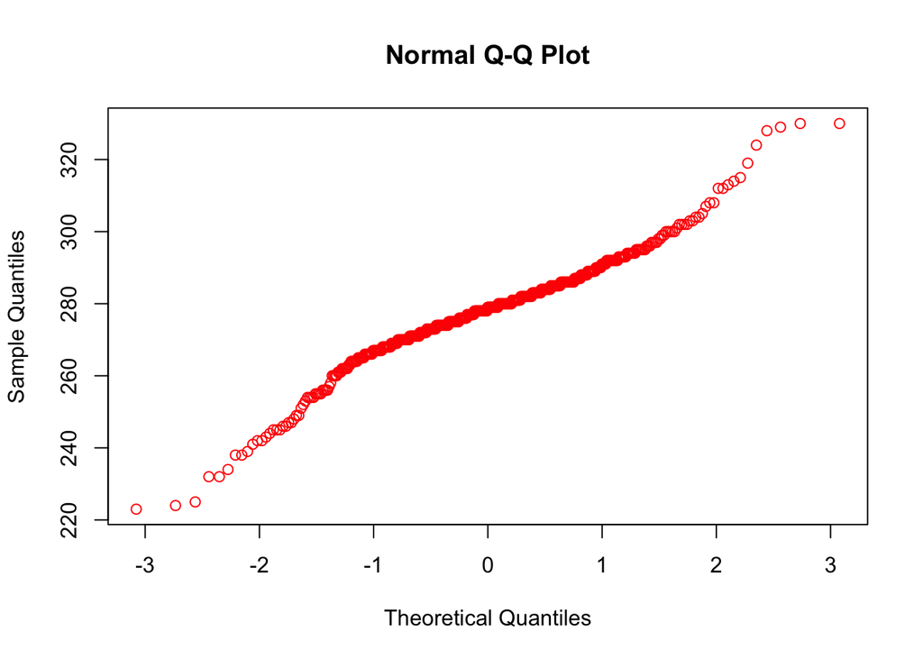

```r
SGestation <- df %>% filter(smoke=="Now")
NSGestation <- df %>% filter(smoke=="Never")
SGestation <- SGestation$gestation
NSGestation <- NSGestation$gestation
A<-qqnorm(SGestation, col= "red")
```

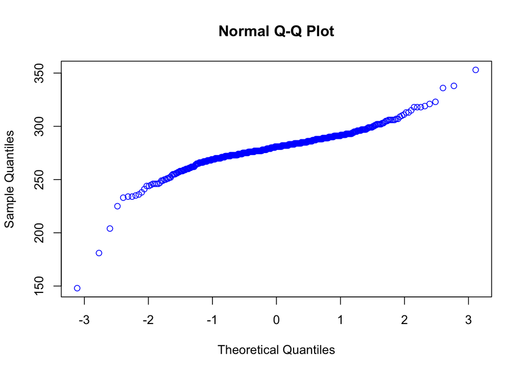

```r
B<-qqnorm(NSGestation, col= "blue")
```

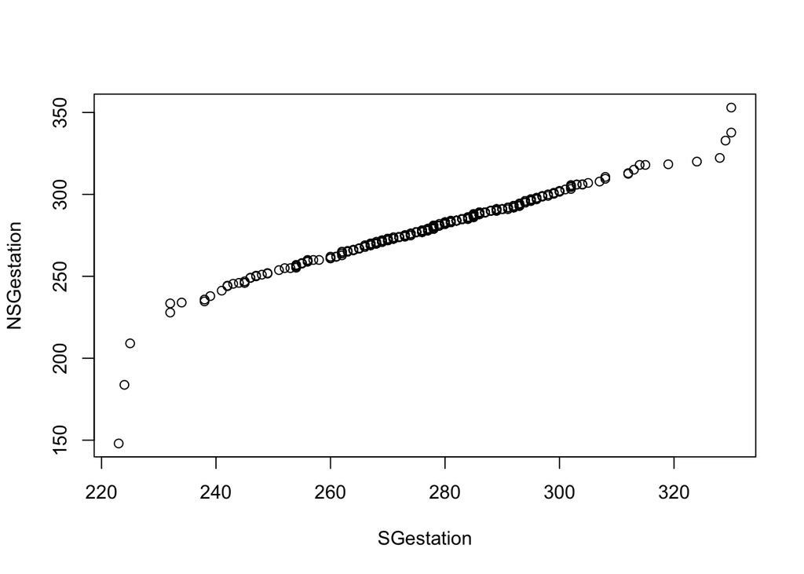

```r
qqplot(SGestation,NSGestation)
```

```r
# from the line in the qqplogt (although seemingly straight) we can conclude that the variance are not the same (by looking at the ends)
```

### c)

Make a t-test and a nonparametric Mann-Whitney test to test the null hypothesis that the mean gestation periods are the same. Which result to you have more confidence in?

```r
#Ho: mean difference in gestation period for smokes and non smokers is the same (=0)
#Ha:  mean difference in gestation period for smokes and non smokers is the same (=!0)

# we reject the Ho for small pvlaue

t.test(SGestation,NSGestation,alternative="two.sided",mu=0,var.equal=FALSE,conf.level = 0.95)
```

```
##
##  Welch Two Sample t-test
##
## data:  SGestation and NSGestation
## t = -1.6688, df = 1015.7, p-value = 0.09546
## alternative hypothesis: true difference in means is not equal to 0
## 95 percent confidence interval:
##  -3.6043579  0.2913157
## sample estimates:
## mean of x mean of y
##  277.9792  279.6357
```

```r
wilcox.test(SGestation,NSGestation,alternative="two.sided",mu=0,conf.level=0.95)
```

```
##
##  Wilcoxon rank sum test with continuity correction
##
## data:  SGestation and NSGestation
## W = 117550, p-value = 0.01349
## alternative hypothesis: true location shift is not equal to 0
```

```r
#From the wilcoxon text the pvalue is smaller than 0.05, which confirm our idea that there is a difference to the gestation period between smokes and nonsmokers. This also can give us clues to answer the question before about variance, by showing that there is a significant difference in the two groups. We fail to reject under the two sided two sample t test. ( on this test we assumed var were not equal from our previous question). The Mann Whitney test appear to be more favorable and useful for us as we did not have to make any assumptions about our distributions (i.e. normality, variability,etc.) I felt more confident in the results the Mann-Whitnet test yields.
```